# ppgmmga

Alessio Serafini, Luca Scrucca

20 Sep 2018

# Introduction

```r
library(ppgmmga)
```

# Banknote data

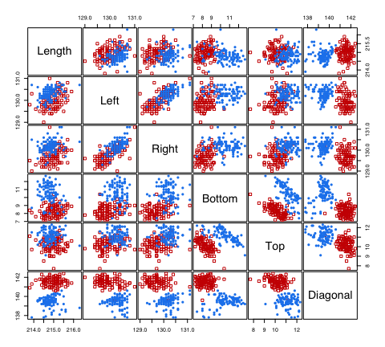

```r
library(mclust)
## Package 'mclust' version 5.4.1
## Type 'citation("mclust")' for citing this R package in publications.
data("banknote")
X <- banknote[,-1]
Class <- banknote$Status
table(Class)
## Class
## counterfeit     genuine
##         100         100
clPairs(X, classification = Class)
```

# Projection Pursuit based on GMMs and GA

## 1 dimensional ppgmmga

```r
pp1D <- ppgmmga(data = X, d = 1, approx = "UT", seed = 1)
pp1D
```

```
## Call:
## ppgmmga(data = X, d = 1, approx = "UT", seed = 1)
##
## 'ppgmmga' object containing:
## [1] "data"       "d"          "approx"     "GMM"        "GA"
## [6] "Negentropy" "basis"      "Z"
```

```r
summary(pp1D)
```

```
## -------------------------------------------------------
## Projection Pursuit GMM estimated via Genetic Algorithms
## -------------------------------------------------------
##
## Data dimensions               = 200 x 6
## Data transformation           = center & scale
## Projection subspace dimension = 1
## GMM density estimate          = (VEE,4)
## Negentropy approximation      = UT
## GA optimal negentropy         = 0.6345935
## GA encoded basis solution:
##             x1       x2       x3       x4      x5
## [1,] 0.1271441 0.768548 2.090229 2.828457 2.60983
##
## Estimated projection basis:
##                  PP1
## Length   -0.01195096
## Left     -0.09348839
## Right     0.16020948
## Bottom    0.57406792
## Top       0.34503491
## Diagonal -0.71892069
```

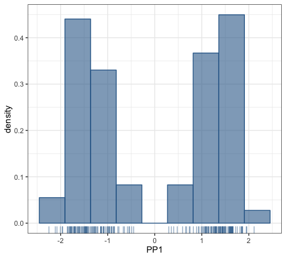

```r
plot(pp1D)
```

## 2 dimensional ppgmmga

```r
pp2D <- ppgmmga(data = X, d = 2, approx = "UT", seed = 1)
summary(pp2D,check = TRUE)
```

```
## -------------------------------------------------------
## Projection Pursuit GMM estimated via Genetic Algorithms
## -------------------------------------------------------
##
## Data dimensions               = 200 x 6
## Data transformation           = center & scale
## Projection subspace dimension = 2
## GMM density estimate          = (VEE,4)
## Negentropy approximation      = UT
## GA optimal negentropy         = 1.13624
## GA encoded basis solution:
##            x1       x2       x3       x4        x5       x6        x7
## [1,] 2.054664 2.967981 1.165038 1.434219 0.3099741 3.919459 0.8487609
##           x8        x9      x10
## [1,] 1.12541 0.1776531 1.866112
##
## Estimated projection basis:
##                  PP1         PP2
## Length   -0.04245658 -0.06888402
## Left      0.02231250 -0.12180144
## Right    -0.14974315  0.07428817
## Bottom   -0.02160955  0.86787505
## Top      -0.06818349  0.46668619
## Diagonal  0.98496732  0.06243044
##
## Monte Carlo Negentropy approximation check:
##                            UT
## Approx Negentropy 1.136240194
## MC Negentropy     1.137312828
## MC se             0.003537725
## Relative accuracy 0.999056870
```

```r
summary(pp2D$GMM)
```

```
## -------------------------------------------------------
## Density estimation via Gaussian finite mixture modeling
## -------------------------------------------------------
##
## Mclust VEE (ellipsoidal, equal shape and orientation) model with 4
## components:
##
##  log.likelihood   n df       BIC       ICL
##       -1191.595 200 51 -2653.405 -2666.898
##
## Clustering table:
##  1  2  3  4
## 16 99 47 38
```

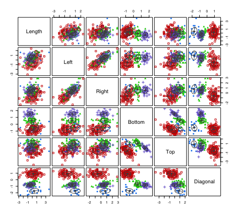

```r
plot.Mclust(pp2D$GMM, what = "classification")
```

```r
summary(pp2D$GA)
```

```
## ── Genetic Algorithm ───────────────────
##
## GA settings:
## Type                  =  real-valued
## Population size       =  100
## Number of generations =  1000
## Elitism               =  1
## Crossover probability =  0.8
## Mutation probability  =  0.1
## Search domain =
##             x1       x2       x3       x4       x5       x6       x7
## lower 0.000000 0.000000 0.000000 0.000000 0.000000 0.000000 0.000000
## upper 6.283185 3.141593 3.141593 3.141593 3.141593 6.283185 3.141593
##             x8       x9      x10
## lower 0.000000 0.000000 0.000000
## upper 3.141593 3.141593 3.141593
##
## GA results:
## Iterations             = 134
## Fitness function value = 1.13624
## Solution =
##            x1       x2       x3       x4        x5       x6        x7
## [1,] 2.054664 2.967981 1.165038 1.434219 0.3099741 3.919459 0.8487609
##           x8        x9      x10
## [1,] 1.12541 0.1776531 1.866112
```

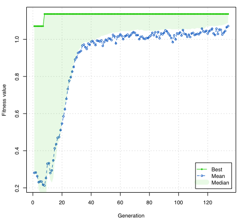

```r
plot(pp2D$GA)
```

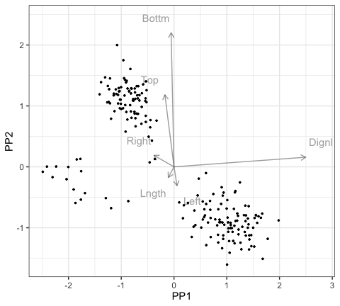

```r
plot(pp2D)
```

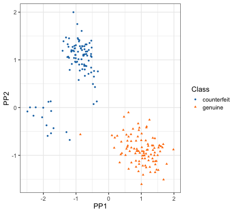

```r
plot(pp2D, class = Class, drawAxis = FALSE)
```

## 3 dimension ppgmmga

```r
gmm <- densityMclust(data = scale(X, center = TRUE, scale = FALSE), G = 2)
pp3D <- ppgmmga(data = X, d = 3, scale = FALSE, gmm = gmm, gatype = "gaisl", options = ppgmmga.options(numIslands = 2, parallel = TRUE),seed = 1)
summary(pp3D$GA)
```

```
## ── Islands Genetic Algorithm ───────────
##
## GA settings:
## Type                  =  real-valued
## Number of islands     =  2
## Islands pop. size     =  50
## Migration rate        =  0.1
## Migration interval    =  10
## Elitism               =  1
## Crossover probability =  0.8
## Mutation probability  =  0.1
## Search domain =
##             x1       x2       x3       x4       x5       x6       x7
## lower 0.000000 0.000000 0.000000 0.000000 0.000000 0.000000 0.000000
## upper 6.283185 3.141593 3.141593 3.141593 3.141593 6.283185 3.141593
##             x8       x9      x10      x11      x12      x13      x14
## lower 0.000000 0.000000 0.000000 0.000000 0.000000 0.000000 0.000000
## upper 3.141593 3.141593 3.141593 6.283185 3.141593 3.141593 3.141593
##            x15
## lower 0.000000
## upper 3.141593
##
## GA results:
## Iterations              = 170
## Epochs                  = 17
## Fitness function values = 0.8572447 0.8572447
## Solutions =
##            x1        x2       x3        x4       x5       x6       x7
## [1,] 3.136482 0.4300163 1.192009 0.1691142 2.923082 1.899629 1.276144
## [2,] 3.136482 0.4300163 1.192009 0.1691142 2.923082 1.899629 1.276144
##            x8        x9       x10      x11     x12      x13      x14
## [1,] 0.961778 0.5946145 0.4716221 3.634149 2.60057 1.237609 1.226115
## [2,] 0.961778 0.5946145 0.4716221 3.634149 2.60057 1.237609 1.226115
##           x15
## [1,] 1.270925
## [2,] 1.270925
```

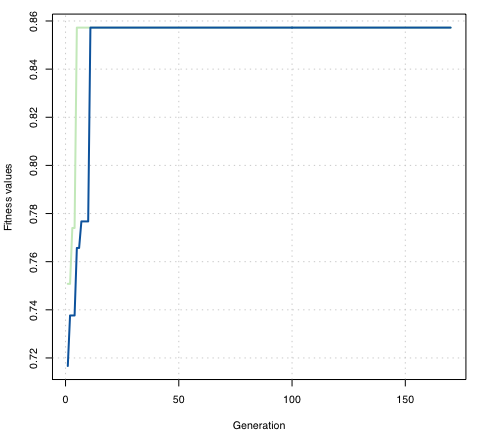

```r
plot(pp3D$GA)
```

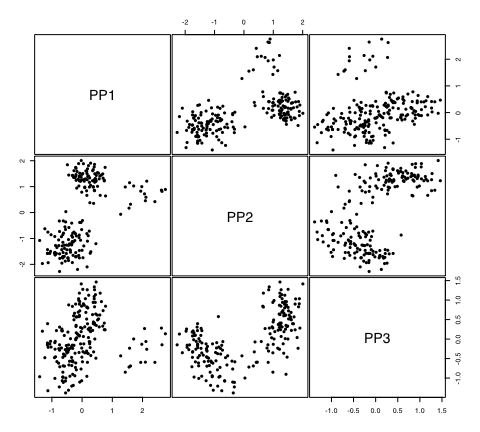

```r
plot(pp3D)
```

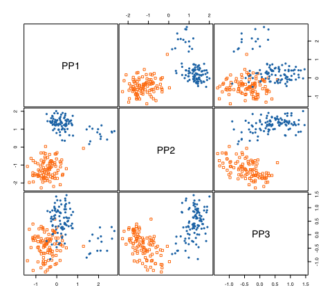

```r
plot(pp3D, class = Class)
```

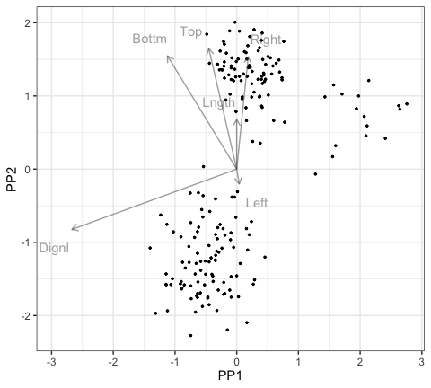

```r
plot(pp3D, dim = c(1,2))
```

# Entropy for GMMs

```r
EntropyUT <- EntropyGMM(G = gmm$G, pro = gmm$parameters$pro, mean = gmm$parameters$mean, sigma = gmm$parameters$variance$sigma, d = gmm$d, method = "UT")
EntropyMC <- EntropyGMM(G = gmm$G, pro = gmm$parameters$pro, mean = gmm$parameters$mean, sigma = gmm$parameters$variance$sigma, d = gmm$d, method = "MC")
c(EntropyUT, EntropyMC)
```

```
## $Entropy
## [1] 3.7777
##
## $method
## [1] "UT"
##
## $Entropy
## [1] 3.76982
##
## $se
## [1] 0.005480339
##
## $method
## [1] "MC"
```

# Negentropy for GMMs

```r
NegentropyUT <- NegentropyGMM(G = gmm$G, pro = gmm$parameters$pro, mean = gmm$parameters$mean, sigma = gmm$parameters$variance$sigma, cov  = cov(X) ,d = gmm$d, method = "UT")
NegentropyMC <- NegentropyGMM(G = gmm$G, pro = gmm$parameters$pro, mean = gmm$parameters$mean, sigma = gmm$parameters$variance$sigma, cov  = cov(X) ,d = gmm$d, method = "MC")
c(NegentropyUT, NegentropyMC)
```

```
## $Negentropy
## [1] 0.8270536
##
## $se
## [1] NA
##
## $method
## [1] "UT"
##
## $Negentropy
## [1] 0.8280628
##
## $se
## [1] 0.005468455
##
## $method
## [1] "MC"
```

```r
gmm1 <- densityMclust(data = X, G = 1)
NegentropyUT1 <- NegentropyGMM(G = gmm$G, pro = gmm$parameters$pro, mean = gmm$parameters$mean, sigma = gmm$parameters$variance$sigma, cov  = cov(X) ,d = gmm$d, method = "UT")
NegentropyUT1
```

```
## $Negentropy
## [1] 0.8270536
##
## $se
## [1] NA
##
## $method
## [1] "UT"
```

# References

Goldberger, J. and Aronowitz, H. (2005). *A distance measure between GMMs based on the unscented transform and its application to speaker recognition.* In INTERSPEECH, pages 1985–1988. Citeseer.

Hershey, J. R. and Olsen, P. A. (2007). *Approximating the Kullback Leibler divergence between Gaussian mixture models.* In 2007 IEEE International Conference on Acoustics, Speech and Signal Processing-ICASSP’07, volume 4, pages IV–317. IEEE.

Huber, P. J. (1985). *Projection pursuit*. The Annals of Statistics, pages 435–475.

Huber, M. F., Bailey, T., Durrant-Whyte, H., and Hanebeck, U. D. (2008). *On entropy approximation for Gaussian mixture random vectors.* In Multisensor Fusion and Integra- tion for Intelligent Systems, 2008. MFI 2008. IEEE International Conference on, pages 181–188. IEEE.

Jones, M. C. and Sibson, R. (1987). *What is projection pursuit? (with discussion).* Journal of the Royal Statistical Society. Series A (General), pages 1–37.

Kruskal, J. B. (1969). *Toward a practical method which helps uncover the structure of a set of multivariate observations by finding the linear transformation which optimizes a new index of condensation.* In Milton, R. C. and Nelder, J. A., editors, Statistical Computation, pages 427–440. Academic Press, New York.